# Results from Differential Methylation Analysis

### Description

This write-up is to look at the results from the differential methylation analysis that used a binomial mixed model implemented in lme4 with the `glmer` function and `family=binomial`. In the model I evaluated all CpG loci in genic regions that were a abover the `min5` coverage threshold for each sample at each locus (roughly 290K loci) using the model described below. I follow up the model with planned comparisons using the package `multcomp`. Specifically, I was interested in the comparing between treatments at each time point and between time points at the ambient (control) treatment. Here I evaluate the general significance results from this analysis, and also take a close look at a handful of loci (focusing mostly on the most significant) to see how the models met the assumptions, and whether there is any evidence that the response variable is being explained by the random effects.

**Model**

```r
Model <- glmer(cbind(methylated,unmethylated)~Time.Treatment.Factor+(1|tank:shelf),family=binomial)
```

**Parameters**

- **Response variable** : 23 row x 2 column matrix with methylated counts in the first column and unmethylated counts in the second column.
- **Explanatory variable : Time.Treatment.Factor** : factor that contains four levels for each combination of time (2 time points) and treatment (ambient, high oa).
- **Random Effects** : tank:shelf or tank nest in shelf to account for random tank effects.

### Outputs and Results

- Model object list (very larger)

### Other Thoughts

- I also considered using `MACAU` as an outside model test. This is a package that performs a similar binomial mixed model, and was specifically designed for bisulfite seq. data. However, it requires a relatedness matrix. This is something we don’t currently have, although something that could be generated potentially using `BIS-seq`, which is yet another package that identifes likely SNPs within your bisulfite seq. data.

### Library and Data

```r
library(lme4,quietly = TRUE)
library(lmerTest,quietly = TRUE)
library(multcomp,quietly = TRUE)
library(dplyr,quietly = TRUE)
```

```r
library(corrplot,quietly = TRUE)
library(MACAU2,quietly = TRUE)
setwd("/home/downeyam/Github/2017OAExp_Oysters/input_files")
beta <- readRDS("DNAm/Final_beta_gene_10.RData")
meta <- readRDS("DNAm/Final_meta_gene_10.RData")
meta_sample <- readRDS("meta/metadata_20190811.RData")
meta_sample <- meta_sample[meta_sample$ID != "17099",]
tC <- readRDS("DNAm/Final_tC_gene_5.RData")
mC <- readRDS("DNAm/Final_mC_gene_10.RData")
uC <- readRDS("DNAm/Final_umC_gene_5.RData")
uC <- uC[which(!is.na(uC[,1])),]

meta_sample$tank <- as.factor(meta_sample$tank)
meta_sample$shelf <- as.factor(meta_sample$shelf)

diffMeth_pValue <- readRDS("DNAm/DNAm_gene_GLM_modelSummary_wRandTank.RData")
diffMeth_betas <- readRDS("DNAm/Final_beta_gene_5.RData")

diffGene <- readRDS("/home/downeyam/Github/2017OAExp_Oysters/results/DiffExpression_gene_Limma_voom_summaryObject.RData")
```

### T score vs P value

```r
par(mfrow=c(1,2))
plot(diffMeth_pValue$t_score[abs(diffMeth_pValue$t_score[,5]) < 100,5]~diffMeth_pValue$pval[abs(diffMeth_pValue$t_score[,5]) < 100,5],
     xlab = "Uncorrected P value", ylab="t score",main="PC: Time09:Trt400 vs Time09:Trt2800")

plot(diffMeth_pValue$t_score[abs(diffMeth_pValue$t_score[,5]) < 100,5]~diffMeth_pValue$pval[abs(diffMeth_pValue$t_score[,5]) < 100,5],
     xlab = "Uncorrected P value", ylab="t score",main="PC: Time09:Trt400 vs Time09:Trt2800",
     xlim=c(0,0.05))

### Figure takes time so was generated ahead of time, be sure link in final document
```

[output not shown]

## Examining the top 10 most significant loci

### Betas by different grouping variables (including random effects)

```
## [1] "Loci 1"
```

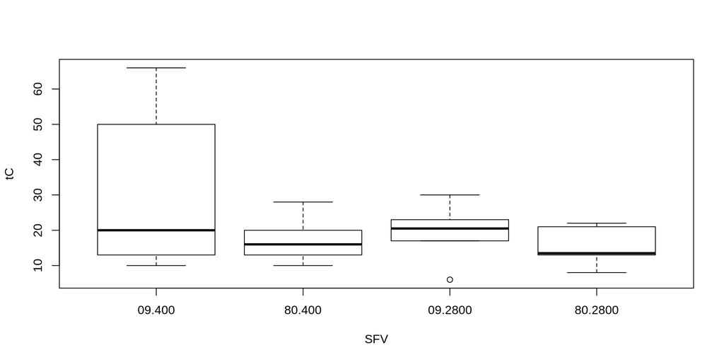

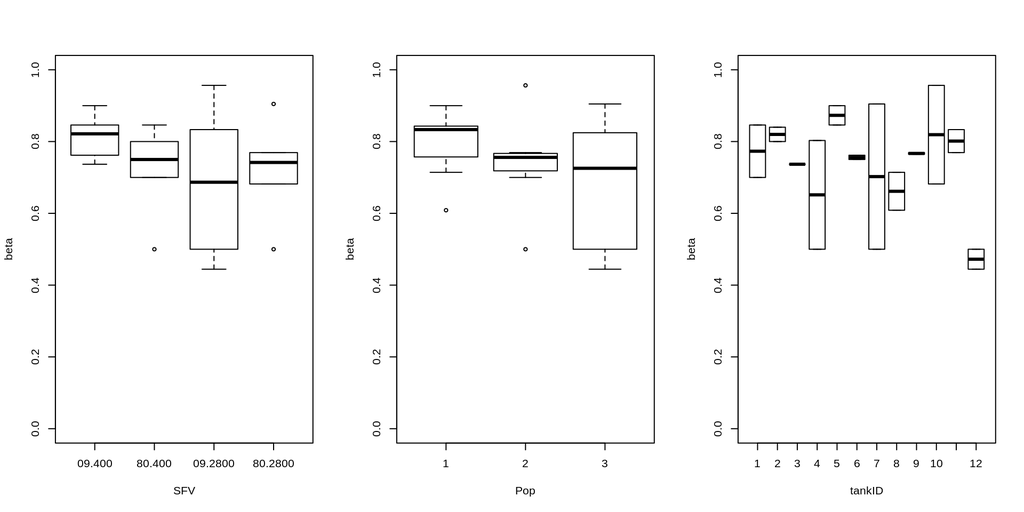

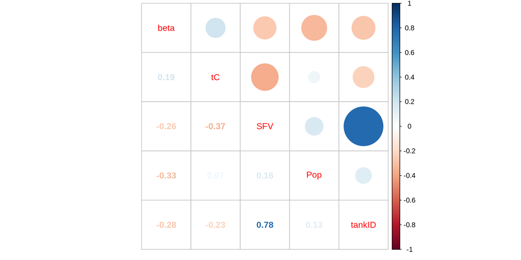

```
## [1] "Loci 2"
```

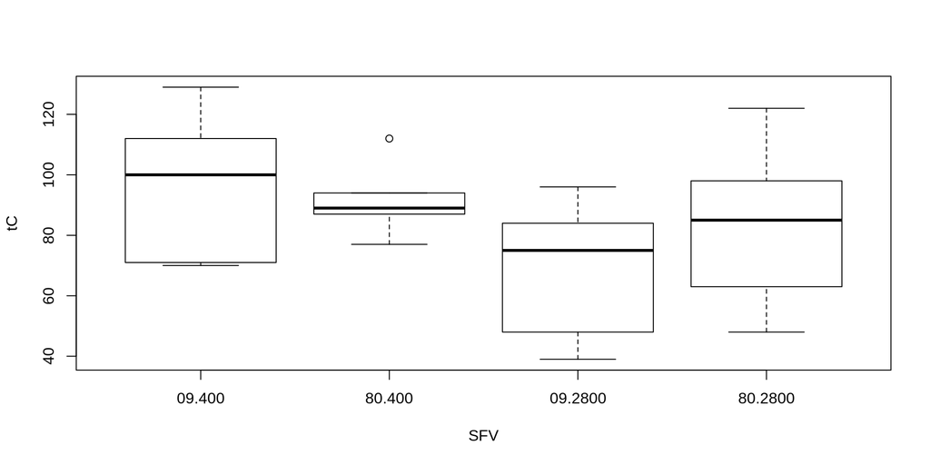

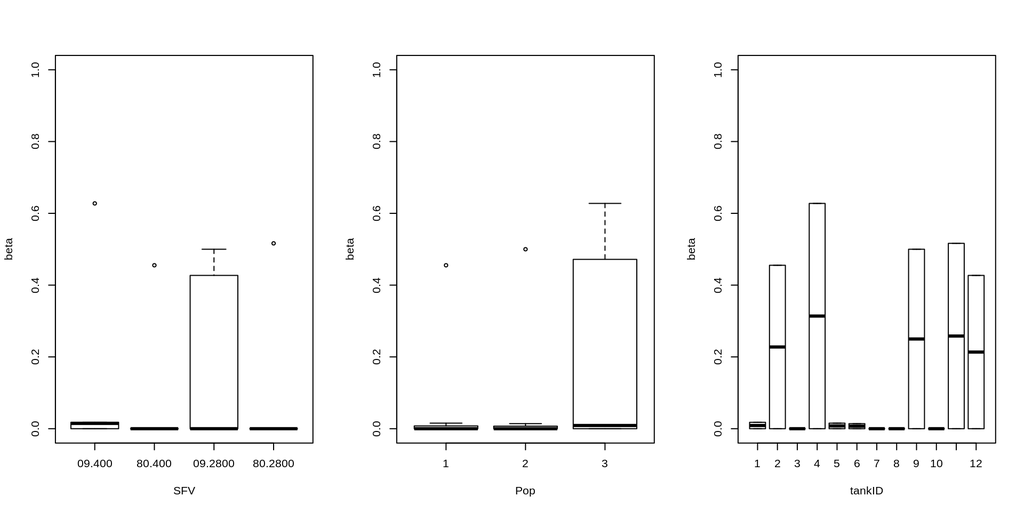

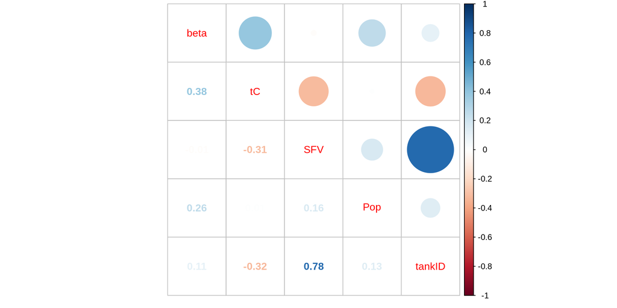

```
## [1] "Loci 3"
```

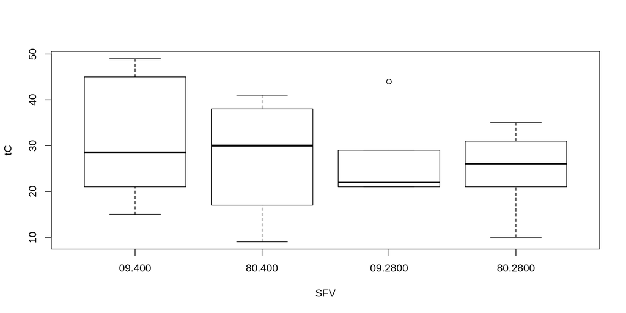

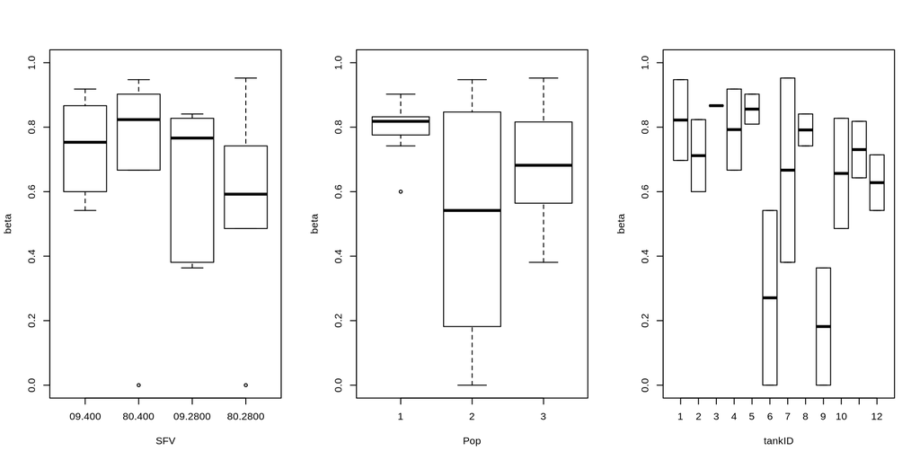

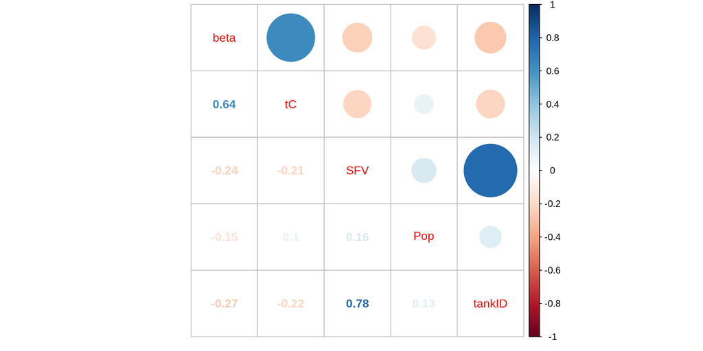

```
## [1] "Loci 4"
```

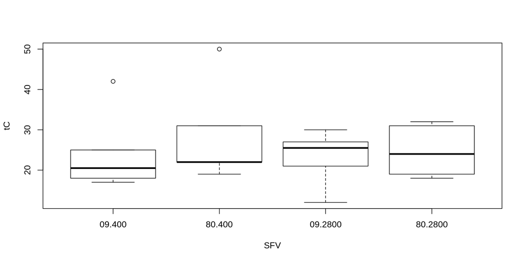

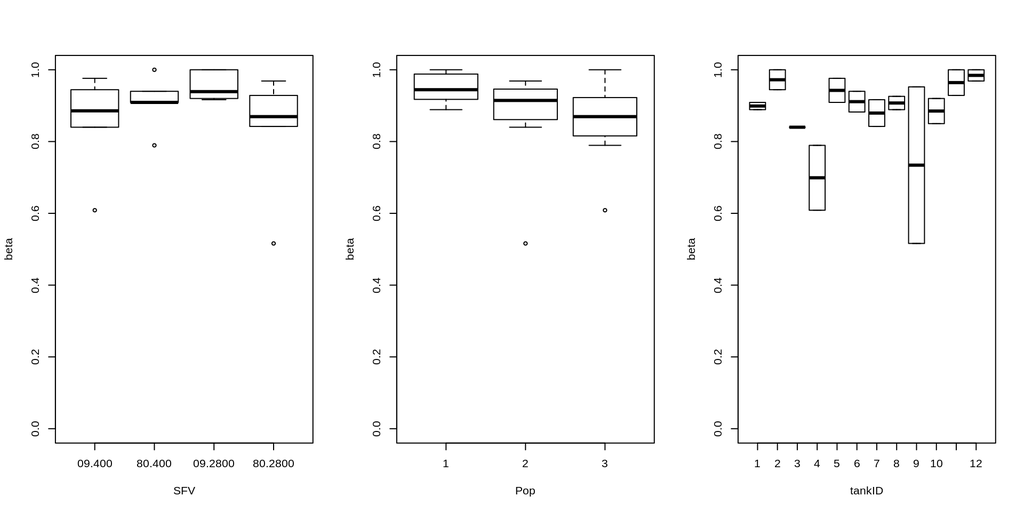

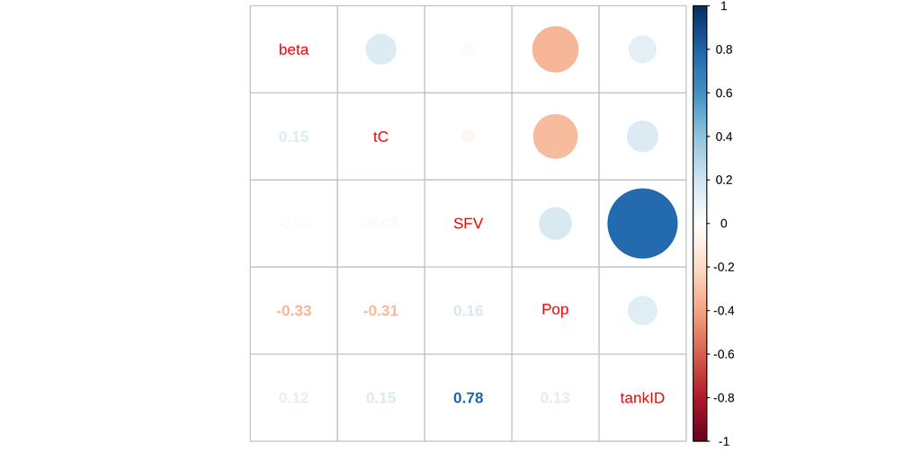

```
## [1] "Loci 5"
```

[18 more figures not shown]

```r
#Give row names a number for ordering
rownames(diffMeth_pValue$t_score)<-1:nrow(diffMeth_pValue$t_score)
#Reorder tvalues from largest to smallest (absolute values)
diffMeth_pValue$t_score<-diffMeth_pValue$t_score[rev(order(abs(diffMeth_pValue$t_score[,5]))),]
# Create vector of indexs ordered by there descending T values
minT <- as.numeric(rownames(diffMeth_pValue$t_score))
# Loop Through and produce some diagnostic plots looking at the relationship between
# Methylation (represented as either beta or total counts (tC))
loci <- 1:10
for(j in 1:length(loci)){
  print(paste0("Loci ",j))
  Sys.sleep(0.01)
  i <- loci[j]
  temp <- data.frame(beta=unlist(diffMeth_betas[minT[i],]),tC=unlist(tC[minT[i],]),
                     SFV=meta_sample$SFV,Pop=meta_sample$Pop,tankID=as.factor(meta_sample$tankID))
  par(mfrow=c(1,1))
  boxplot(tC~SFV,data=temp)
  par(mfrow=c(1,3))
  boxplot(beta~SFV,data=temp,ylim=c(0,1))
  boxplot(beta~Pop,data=temp,ylim=c(0,1))
  boxplot(beta~tankID,data=temp,ylim=c(0,1))
  par(mfrow=c(1,1))
  temp$SFV <- as.numeric(temp$SFV)
  temp$Pop <- as.numeric(temp$Pop)
  temp$tankID <- as.numeric(temp$tankID)
  M <- cor(temp)
  corrplot.mixed(M)
}
```